# Analisis Data Kategorik Karakteristik Deteksi Hotspot Karhutla di Indonesia (11-12 November 2026)

Wa Ode Nisrina Sayyidah Hidayat

12 November 2026

# 1 Pendahuluan

## 1.1 Latar Belakang

Kebakaran hutan dan lahan (karhutla) di Indonesia dipantau salah satunya melalui titik panas (*hotspot*) yang dideteksi satelit penginderaan jauh. Hotspot menunjukkan lokasi yang suhunya terbaca tinggi oleh sensor satelit, tetapi **tidak otomatis berarti kebakaran**: titik tersebut dapat berupa api, dapat pula sumber panas lain. Karena itu, setiap hotspot disertai tingkat kepercayaan (*confidence*) yang menunjukkan seberapa yakin sistem bahwa titik tersebut merupakan api.

Aturan penentuan *confidence* berbeda pada tiap satelit dan sensor, sehingga memahami faktor-faktor yang berkaitan dengan tingkat kepercayaan penting bagi pengguna data, misalnya untuk menentukan prioritas verifikasi lapangan. Laporan ini menganalisis data hotspot pada 11-12 November 2026 menggunakan metode analisis data kategorik.

## 1.2 Rumusan Masalah

1. Apakah tingkat kepercayaan hotspot (*confidence*) berhubungan dengan satelit pendeteksi, sesi waktu deteksi (siang/malam), dan wilayah pulau?
2. Bagaimana pengaruh satelit, sesi waktu, dan wilayah terhadap peluang suatu hotspot berkategori *confidence* rendah, setelah ketiganya dikontrol bersama dan ketergantungan antartitik diperhitungkan?
3. Bagaimana perbedaan peluang kategori *Low* dan *High* dibandingkan *Medium* menurut karakteristik deteksi tersebut, dan seberapa stabil temuan ini terhadap wilayah dengan jumlah titik yang sangat dominan?

## 1.3 Tujuan

1. Menguji dan mengukur kekuatan asosiasi antara *confidence* dan satelit, sesi waktu, serta pulau.
2. Memodelkan peluang hotspot berkepercayaan rendah dengan regresi logistik biner.
3. Memodelkan tiga kategori *confidence* sekaligus dengan regresi logistik multinomial.
4. Menguji ketahanan temuan terhadap ketergantungan antartitik dan terhadap satu kabupaten yang mendominasi data.

## 1.4 Manfaat

Hasil analisis membantu pengguna data hotspot memahami bahwa kualitas keyakinan deteksi bergantung pada karakteristik pengamatan (satelit dan waktu), sehingga dapat dijadikan pertimbangan dalam menafsirkan dan memprioritaskan titik panas untuk verifikasi.

# 2 Tinjauan Pustaka

**Uji chi-square independensi.** Menguji apakah dua variabel kategorik saling bebas dengan membandingkan frekuensi teramati dan harapan; kekuatan hubungannya diukur dengan Cramér’s V dan sel-sel penyebab ketidakbebasan diidentifikasi lewat residual terstandarisasi (Agresti, 2013).

**Regresi logistik biner dan multinomial.** Regresi logistik biner memodelkan log-odds suatu kejadian dan dibaca melalui *odds ratio* (OR = e^β). Regresi logistik multinomial memperluasnya untuk respons nominal dengan lebih dari dua kategori, dengan satu kategori sebagai acuan (Hosmer, Lemeshow, & Sturdivant, 2013).

**Galat baku *cluster-robust*.** Bila pengamatan dalam satu kelompok saling berkaitan (di sini, titik-titik pada kabupaten/kota yang sama), galat baku biasa cenderung terlalu kecil sehingga p-value terlalu optimistis. Galat baku *cluster-robust* mengoreksi hal ini (Cameron & Miller, 2015; Zeileis, Köll, & Graham, 2020).

# 3 Metodologi

## 3.1 Data

Data berupa sheet *Detail* pada file `sebaran-hotspot.xlsx`, yaitu 3.350 titik hotspot pada **11-12 November 2026** di 33 provinsi dan 184 kabupaten/kota. Satu baris mewakili satu titik hotspot.

## 3.2 Variabel Penelitian

| Variabel | Peran | Kategori | Asal kolom | Acuan |
| --- | --- | --- | --- | --- |
| *Confidence* | Respons | *Low*, *Medium*, *High* (biner: *Low* = 1, lainnya = 0) | `Confidence` | *Medium* (multinomial) |
| Satelit | Prediktor | NASA-NOAA21, NASA-NOAA20, NASA-MODIS | `Satelit` | NASA-NOAA21 |
| Sesi | Prediktor | Siang (06.00-17.59 WIB), Malam (di luar itu) | turunan dari `Waktu` | Malam |
| Pulau | Prediktor (biner) | Sumatera, Jawa, Bali-Nusa Tenggara, Kalimantan, Sulawesi, Maluku-Papua | turunan dari `Provinsi` | Kalimantan |
| Wilayah | Prediktor (multinomial) | Maluku-Papua, Lainnya | turunan dari `Pulau` | Lainnya |

Pada model multinomial, pulau diringkas menjadi dua kelompok karena Kalimantan dan Jawa tidak memiliki satu pun hotspot *High* sehingga model dengan enam kategori pulau mengalami separasi sempurna.

## 3.3 Tahapan Analisis

1. Persiapan data dan pembentukan variabel turunan.
2. Statistik deskriptif.
3. Uji chi-square independensi (satelit, sesi, pulau terhadap *confidence*) dengan Cramér’s V dan residual terstandarisasi.
4. Regresi logistik biner (*Low* vs bukan *Low*), disertai galat baku *cluster-robust* per kabupaten/kota.
5. Regresi logistik multinomial (*Low*, *Medium*, *High*) dengan selang kepercayaan bootstrap per klaster.
6. Analisis sensitivitas dengan mengeluarkan kabupaten yang paling dominan.

Hipotesis uji chi-square: H0 = *confidence* dan variabel pasangannya saling bebas; H1 = keduanya berhubungan. Taraf signifikansi α = 5%.

# 4 Hasil dan Pembahasan

## 4.1 Persiapan Data

```r
path <- "D:/1. KULIAH/Semester 3/[ANDAKAT]/PROJECT"
hot <- read_excel(file.path(path, "sebaran-hotspot.xlsx"), sheet = "Detail")

pulau <- list(
  "Sumatera"           = c("Aceh","Sumatera Utara","Sumatera Barat","Riau","Kepulauan Riau","Jambi",
                           "Sumatera Selatan","Bangka Belitung","Bengkulu","Lampung"),
  "Jawa"               = c("Banten","DKI Jakarta","Jawa Barat","Jawa Tengah","Yogyakarta","Jawa Timur"),
  "Bali-Nusa Tenggara" = c("Bali","Nusa Tenggara Barat","Nusa Tenggara Timur"),
  "Kalimantan"         = c("Kalimantan Barat","Kalimantan Tengah","Kalimantan Selatan",
                           "Kalimantan Timur","Kalimantan Utara","IKN"),
  "Sulawesi"           = c("Sulawesi Utara","Gorontalo","Sulawesi Tengah","Sulawesi Barat",
                           "Sulawesi Selatan","Sulawesi Tenggara"),
  "Maluku-Papua"       = c("Maluku","Maluku Utara","Papua","Papua Barat","Papua Barat Daya",
                           "Papua Selatan","Papua Tengah","Papua Pegunungan")
)
peta_pulau <- stack(pulau) %>% rename(Provinsi = values, Pulau = ind) %>%
  mutate(Provinsi = as.character(Provinsi), Pulau = as.character(Pulau))

hot <- hot %>%
  mutate(Provinsi = dplyr::recode(Provinsi, "Kepulauan Bangka Belitung" = "Bangka Belitung"),
         KabKota  = `Kab Kota`,
         klaster  = paste(Provinsi, KabKota, sep = "|"),
         jam      = as.integer(substr(Waktu, 1, 2)),
         Sesi     = ifelse(jam >= 6 & jam < 18, "Siang", "Malam")) %>%
  left_join(peta_pulau, by = "Provinsi")

stopifnot(nrow(hot) == 3350, !any(is.na(hot$Pulau)), !anyNA(hot$Confidence))

hot <- hot %>%
  mutate(
    Confidence  = factor(Confidence, levels = c("Low", "Medium", "High")),
    conf_rendah = as.integer(Confidence == "Low"),
    Satelit     = relevel(factor(Satelit), ref = "NASA-NOAA21"),
    Sesi        = relevel(factor(Sesi),    ref = "Malam"),
    Pulau       = relevel(factor(Pulau),   ref = "Kalimantan"),
    Wilayah     = relevel(factor(ifelse(Pulau == "Maluku-Papua", "Maluku-Papua", "Lainnya")), ref = "Lainnya")
  )

c(titik = nrow(hot), provinsi = n_distinct(hot$Provinsi), kabkota = n_distinct(hot$klaster))
```

```
##    titik provinsi  kabkota
##     3350       33      184
```

## 4.2 Statistik Deskriptif

```r
tab_frek <- function(x, nama) {
  t <- table(x)
  data.frame(Variabel = nama, Kategori = names(t), Frekuensi = as.integer(t),
             Persen = round(100 * as.numeric(prop.table(t)), 1))
}
deskriptif <- rbind(tab_frek(hot$Confidence, "Confidence"), tab_frek(hot$Satelit, "Satelit"),
                    tab_frek(hot$Sesi, "Sesi"),             tab_frek(hot$Pulau, "Pulau"))
kable(deskriptif, caption = "Distribusi variabel penelitian (n = 3.350)")
```

Distribusi variabel penelitian (n = 3.350)

| Variabel | Kategori | Frekuensi | Persen |
| --- | --- | --- | --- |
| Confidence | Low | 268 | 8.0 |
| Confidence | Medium | 2992 | 89.3 |
| Confidence | High | 90 | 2.7 |
| Satelit | NASA-NOAA21 | 1586 | 47.3 |
| Satelit | NASA-MODIS | 218 | 6.5 |
| Satelit | NASA-NOAA20 | 1546 | 46.1 |
| Sesi | Malam | 1473 | 44.0 |
| Sesi | Siang | 1877 | 56.0 |
| Pulau | Kalimantan | 614 | 18.3 |
| Pulau | Bali-Nusa Tenggara | 157 | 4.7 |
| Pulau | Jawa | 61 | 1.8 |
| Pulau | Maluku-Papua | 1437 | 42.9 |
| Pulau | Sulawesi | 828 | 24.7 |
| Pulau | Sumatera | 253 | 7.6 |

```r
hot %>% count(KabKota, Provinsi, sort = TRUE) %>% head(5)
```

| KabKota | Provinsi | n |
| --- | --- | --- |
| MERAUKE | Papua Selatan | 1030 |
| KUTAI KARTANEGARA | Kalimantan Timur | 197 |
| HALMAHERA SELATAN | Maluku Utara | 153 |
| MOROWALI | Sulawesi Tengah | 141 |
| KONAWE | Sulawesi Tenggara | 138 |

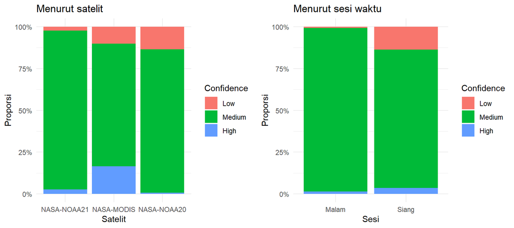

```r
g1 <- ggplot(hot, aes(Satelit, fill = Confidence)) + geom_bar(position = "fill") +
  scale_y_continuous(labels = scales::percent) + labs(y = "Proporsi", title = "Menurut satelit") + theme_minimal()
g2 <- ggplot(hot, aes(Sesi, fill = Confidence)) + geom_bar(position = "fill") +
  scale_y_continuous(labels = scales::percent) + labs(y = "Proporsi", title = "Menurut sesi waktu") + theme_minimal()
gridExtra::grid.arrange(g1, g2, ncol = 2)
```

**Interpretasi.** Sebagian besar hotspot berkategori *Medium* (2.992 titik; 89,3%), sedangkan *Low* berjumlah 268 titik (8,0%) dan *High* hanya 90 titik (2,7%). Menurut satelit, NASA-NOAA21 (47,3%) dan NASA-NOAA20 (46,1%) mendominasi, sedangkan NASA-MODIS hanya 6,5%. Deteksi siang hari lebih banyak (56,0%) dibanding malam (44,0%). Menurut pulau, Maluku-Papua menyumbang 42,9% titik, disusul Sulawesi (24,7%), Kalimantan (18,3%), Sumatera (7,6%), Bali-Nusa Tenggara (4,7%), dan Jawa (1,8%).

Satu temuan penting yang memengaruhi pembacaan seluruh hasil: **Kabupaten Merauke (Papua Selatan) sendirian menyumbang 1.030 titik atau sekitar 30,7% dari seluruh data**. Hal ini diperiksa lebih lanjut pada analisis sensitivitas (bagian 4.6).

## 4.3 Uji Chi-Square Independensi

```r
cramer_v <- function(tbl) {
  chi2 <- suppressWarnings(chisq.test(tbl)$statistic)
  sqrt(unname(chi2) / (sum(tbl) * (min(dim(tbl)) - 1)))
}
uji_chi <- function(tbl, simulasi = FALSE) {
  ex <- suppressWarnings(chisq.test(tbl)$expected)
  cat("Sel dengan frekuensi harapan < 5:", round(100 * mean(ex < 5), 1), "%\n")
  ct <- if (simulasi) chisq.test(tbl, simulate.p.value = TRUE, B = 10000) else chisq.test(tbl)
  print(ct)
  cat("Cramer's V =", round(cramer_v(tbl), 3), "\n")
  invisible(ct)
}
```

### 4.3.1 Satelit dan *Confidence*

```r
t_sat <- table(hot$Satelit, hot$Confidence)
t_sat; round(100 * prop.table(t_sat, 1), 1)
```

```
##
##                Low Medium High
##   NASA-NOAA21   38   1506   42
##   NASA-MODIS    22    160   36
##   NASA-NOAA20  208   1326   12
```

```
##
##                Low Medium High
##   NASA-NOAA21  2.4   95.0  2.6
##   NASA-MODIS  10.1   73.4 16.5
##   NASA-NOAA20 13.5   85.8  0.8
```

```r
uji_chi(t_sat)
```

```
## Sel dengan frekuensi harapan < 5: 0 %
##
##  Pearson's Chi-squared test
##
## data:  tbl
## X-squared = 311.1, df = 4, p-value < 2.2e-16
##
## Cramer's V = 0.215
```

### 4.3.2 Sesi Waktu dan *Confidence*

```r
t_ses <- table(hot$Sesi, hot$Confidence)
t_ses; round(100 * prop.table(t_ses, 1), 1)
```

```
##
##          Low Medium High
##   Malam   12   1439   22
##   Siang  256   1553   68
```

```
##
##          Low Medium High
##   Malam  0.8   97.7  1.5
##   Siang 13.6   82.7  3.6
```

```r
uji_chi(t_ses)
```

```
## Sel dengan frekuensi harapan < 5: 0 %
##
##  Pearson's Chi-squared test
##
## data:  tbl
## X-squared = 204.25, df = 2, p-value < 2.2e-16
##
## Cramer's V = 0.247
```

### 4.3.3 Pulau dan *Confidence*

```r
t_pul <- table(hot$Pulau, hot$Confidence)
t_pul; round(100 * prop.table(t_pul, 1), 1)
```

```
##
##                       Low Medium High
##   Kalimantan           36    578    0
##   Bali-Nusa Tenggara   12    142    3
##   Jawa                  1     60    0
##   Maluku-Papua        201   1174   62
##   Sulawesi             17    792   19
##   Sumatera              1    246    6
```

```
##
##                       Low Medium High
##   Kalimantan          5.9   94.1  0.0
##   Bali-Nusa Tenggara  7.6   90.4  1.9
##   Jawa                1.6   98.4  0.0
##   Maluku-Papua       14.0   81.7  4.3
##   Sulawesi            2.1   95.7  2.3
##   Sumatera            0.4   97.2  2.4
```

```r
ct_pul <- uji_chi(t_pul, simulasi = TRUE)   # sebagian sel harapan < 5 -> simulasi Monte Carlo
```

```
## Sel dengan frekuensi harapan < 5: 16.7 %
##
##  Pearson's Chi-squared test with simulated p-value (based on 10000
##  replicates)
##
## data:  tbl
## X-squared = 176.14, df = NA, p-value = 9.999e-05
##
## Cramer's V = 0.162
```

```r
round(ct_pul$stdres, 2)                     # residual terstandarisasi
```

```
##
##                         Low Medium   High
##   Kalimantan          -2.16   4.28  -4.56
##   Bali-Nusa Tenggara  -0.17   0.47  -0.62
##   Jawa                -1.85   2.31  -1.31
##   Maluku-Papua        11.07 -12.37   5.05
##   Sulawesi            -7.27   6.80  -0.80
##   Sumatera            -4.64   4.24  -0.32
```

Dengan n sebesar ini, hampir semua uji akan signifikan, sehingga **kekuatan hubungan (V)** lebih informatif daripada p-value. Uji chi-square juga mengasumsikan pengamatan independen, padahal titik pada kabupaten yang sama saling berkaitan; karena itu hasil chi-square dibaca sebagai gambaran asosiasi, dan inferensi utama bertumpu pada regresi dengan koreksi klaster. Temuan untuk pulau (terutama Maluku-Papua) perlu dibaca bersama analisis sensitivitas bagian 4.6.

## 4.4 Regresi Logistik Biner

Respons: *Low* = 1, *Medium*/*High* = 0. Prediktor: satelit (acuan NOAA21), sesi (acuan Malam), pulau (acuan Kalimantan).

```r
m1 <- glm(conf_rendah ~ Satelit + Sesi + Pulau, data = hot, family = binomial)
vc <- vcovCL(m1, cluster = hot$klaster)           # galat baku cluster-robust per kab/kota

est <- coef(m1)
ci_b <- confint.default(m1)                       # Wald biasa
ci_r <- coefci(m1, vcov. = vc)                    # Wald cluster-robust
p_r  <- coeftest(m1, vcov. = vc)[, 4]

hasil_logit <- data.frame(
  OR         = exp(est),
  SK_bawah_r = exp(ci_r[, 1]),
  SK_atas_r  = exp(ci_r[, 2]),
  p_robust   = p_r,
  SE_biasa   = sqrt(diag(vcov(m1))),
  SE_robust  = sqrt(diag(vc))
)
round(hasil_logit, 4)
```

|  | OR | SK_bawah_r | SK_atas_r | p_robust | SE_biasa | SE_robust |
| --- | --- | --- | --- | --- | --- | --- |
| (Intercept) | 0.0013 | 0.0001 | 0.0130 | 0.0000 | 0.3879 | 1.1538 |
| SatelitNASA-MODIS | 8.2048 | 3.2470 | 20.7326 | 0.0000 | 0.3161 | 0.4730 |
| SatelitNASA-NOAA20 | 6.3587 | 2.0544 | 19.6813 | 0.0013 | 0.1890 | 0.5765 |
| SesiSiang | 19.6203 | 5.1846 | 74.2500 | 0.0000 | 0.3018 | 0.6790 |
| PulauBali-Nusa Tenggara | 1.1843 | 0.5384 | 2.6051 | 0.6740 | 0.3605 | 0.4022 |
| PulauJawa | 0.8870 | 0.0755 | 10.4279 | 0.9241 | 1.0782 | 1.2573 |
| PulauMaluku-Papua | 3.2554 | 1.4109 | 7.5111 | 0.0057 | 0.2017 | 0.4266 |
| PulauSulawesi | 0.3769 | 0.1614 | 0.8801 | 0.0241 | 0.3105 | 0.4327 |
| PulauSumatera | 0.0551 | 0.0064 | 0.4732 | 0.0082 | 1.0399 | 1.0974 |

```r
# uji simultan (LR, tanpa koreksi klaster) dan kecocokan
m0 <- update(m1, . ~ 1)
lr <- 2 * (logLik(m1) - logLik(m0))
data.frame(LR_chi2 = round(as.numeric(lr), 2), db = length(coef(m1)) - 1,
           McFadden_R2 = round(1 - as.numeric(logLik(m1) / logLik(m0)), 3),
           AUC = round(as.numeric(auc(roc(hot$conf_rendah, fitted(m1), quiet = TRUE))), 3))
```

| LR_chi2 | db | McFadden_R2 | AUC |
| --- | --- | --- | --- |
| 526.67 | 8 | 0.282 | 0.871 |

```r
# uji Wald per variabel dengan matriks kovarians cluster-robust
Anova(m1, vcov. = vc, type = "II", test.statistic = "Wald")
```

|  | Df | Chisq | Pr(>Chisq) |
| --- | --- | --- | --- |
| Satelit | 2 | 21.45432 | 2.194081e-05 |
| Sesi | 1 | 19.21568 | 1.167502e-05 |
| Pulau | 5 | 44.41600 | 1.906805e-08 |

```r
vif(m1)
```

```
##             GVIF Df GVIF^(1/(2*Df))
## Satelit 1.081254  2        1.019722
## Sesi    1.007084  1        1.003536
## Pulau   1.087516  5        1.008425
```

```r
skenario <- data.frame(
  Satelit = factor(c("NASA-NOAA21", "NASA-NOAA20", "NASA-MODIS", "NASA-NOAA20"), levels = levels(hot$Satelit)),
  Sesi    = factor(c("Malam", "Siang", "Siang", "Malam"), levels = levels(hot$Sesi)),
  Pulau   = factor(c("Kalimantan", "Maluku-Papua", "Maluku-Papua", "Sumatera"), levels = levels(hot$Pulau))
)
skenario$peluang <- round(predict(m1, skenario, type = "response"), 4)
skenario
```

| Satelit | Sesi | Pulau | peluang |
| --- | --- | --- | --- |
| NASA-NOAA21 | Malam | Kalimantan | 0.0013 |
| NASA-NOAA20 | Siang | Maluku-Papua | 0.3541 |
| NASA-MODIS | Siang | Maluku-Papua | 0.4143 |
| NASA-NOAA20 | Malam | Sumatera | 0.0005 |

Rasio odds (SK 95% *cluster-robust*), dengan variabel lain dikontrol:

- **Sesi.** Deteksi siang hari: OR ≈ **19,6** (5,2-74,4) dibanding malam. Efek terbesar dalam model.
- **Satelit.** NASA-MODIS: OR ≈ **8,2** (3,2-20,8); NASA-NOAA20: OR ≈ **6,4** (2,1-19,7), keduanya dibanding NOAA21.
- **Pulau (acuan Kalimantan).** Maluku-Papua: OR ≈ **3,3** (1,4-7,5); Sulawesi: OR ≈ 0,38 (0,16-0,88); Sumatera: OR ≈ 0,055 (0,006-0,47). Bali-Nusa Tenggara (OR ≈ 1,18) dan Jawa (OR ≈ 0,89) tidak berbeda nyata dari Kalimantan.

Sebagai gambaran peluang: hotspot NOAA21 pada malam hari di Kalimantan hanya berpeluang sekitar 0,13% berkategori *Low*, sedangkan NOAA20 pada siang hari di Maluku-Papua sekitar 35% dan NASA-MODIS pada siang hari di Maluku-Papua sekitar 41%. Jawa dan Sumatera masing-masing hanya memiliki 1 hotspot *Low*, sehingga estimasi keduanya kurang stabil (selang kepercayaan sangat lebar).

## 4.5 Regresi Logistik Multinomial

Respons: *Confidence* tiga kategori dengan acuan *Medium*. Prediktor: satelit, sesi, dan wilayah (Maluku-Papua vs Lainnya).

```r
hot$Confidence_m <- relevel(hot$Confidence, ref = "Medium")
m3 <- multinom(Confidence_m ~ Satelit + Sesi + Wilayah, data = hot, trace = FALSE)

# kecocokan dan uji simultan (tanpa koreksi klaster)
m3_0 <- multinom(Confidence_m ~ 1, data = hot, trace = FALSE)
lr3 <- 2 * (logLik(m3) - logLik(m3_0))
data.frame(LR_chi2 = round(as.numeric(lr3), 2), db = length(coef(m3)),
           McFadden_R2 = round(1 - as.numeric(logLik(m3) / logLik(m3_0)), 3))
```

| LR_chi2 | db | McFadden_R2 |
| --- | --- | --- |
| 670.48 | 10 | 0.25 |

```r
# OR dengan galat baku biasa
s3 <- summary(m3)
or_biasa <- exp(s3$coefficients)
round(or_biasa, 3)
```

```
##      (Intercept) SatelitNASA-MODIS SatelitNASA-NOAA20 SesiSiang
## Low        0.001             8.227              6.677    20.929
## High       0.005            11.821              0.345     2.994
##      WilayahMaluku-Papua
## Low                5.629
## High               5.141
```

```r
# bootstrap per klaster (kab/kota) untuk selang kepercayaan yang memperhitungkan ketergantungan antartitik
B <- 300
idx_klaster <- split(seq_len(nrow(hot)), hot$klaster)
nama_klaster <- names(idx_klaster)

satu_boot <- function() {
  pilih <- sample(nama_klaster, length(nama_klaster), replace = TRUE)
  d <- hot[unlist(idx_klaster[pilih]), ]
  tryCatch({
    m <- multinom(Confidence_m ~ Satelit + Sesi + Wilayah, data = d, trace = FALSE)
    as.vector(t(coef(m)))
  }, error = function(e) rep(NA_real_, length(coef(m3))))
}
hasil_boot <- t(replicate(B, satu_boot()))

nama_par <- as.vector(t(outer(rownames(coef(m3)), colnames(coef(m3)), paste, sep = ": ")))
colnames(hasil_boot) <- nama_par
ci_boot <- t(apply(hasil_boot, 2, quantile, probs = c(0.025, 0.975), na.rm = TRUE))
tabel_boot <- data.frame(OR = exp(as.vector(t(coef(m3)))),
                         SK_bawah = exp(ci_boot[, 1]), SK_atas = exp(ci_boot[, 2]))
rownames(tabel_boot) <- nama_par
round(tabel_boot[!grepl("Intercept", rownames(tabel_boot)), ], 3)
```

|  | OR | SK_bawah | SK_atas |
| --- | --- | --- | --- |
| Low: SatelitNASA-MODIS | 8.227 | 1.978 | 20.055 |
| Low: SatelitNASA-NOAA20 | 6.677 | 0.913 | 11.414 |
| Low: SesiSiang | 20.929 | 4.158 | 84.128 |
| Low: WilayahMaluku-Papua | 5.629 | 0.722 | 9.766 |
| High: SatelitNASA-MODIS | 11.821 | 6.798 | 41.439 |
| High: SatelitNASA-NOAA20 | 0.345 | 0.093 | 0.738 |
| High: SesiSiang | 2.994 | 0.409 | 8.172 |
| High: WilayahMaluku-Papua | 5.141 | 0.415 | 10.420 |

Dua catatan metodologis: (1) akurasi klasifikasi model tidak dipakai sebagai ukuran karena model hampir selalu memprediksi *Medium* (akurasinya ≈ 89,3%, sama dengan menebak semua titik *Medium*); (2) NOAA20 pada malam hari tidak memiliki satu pun hotspot *Low* maupun *High* (642 titik seluruhnya *Medium*), yang mengisyaratkan interaksi satelit × sesi yang tidak dimodelkan di sini.

## 4.6 Analisis Sensitivitas: Tanpa Kabupaten Merauke

Merauke menyumbang 1.030 titik (30,7%), dengan 184 hotspot *Low* (17,9% dari titik Merauke) dan 48 hotspot *High*. Dengan kata lain, **sekitar 69% seluruh hotspot *Low* berasal dari satu kabupaten**. Model biner diulang tanpa Merauke untuk menguji apakah temuan bergantung padanya.

```r
hot_s <- hot %>% filter(KabKota != "MERAUKE")
c(n = nrow(hot_s), low = sum(hot_s$conf_rendah), persen_low = round(100 * mean(hot_s$conf_rendah), 1))
```

```
##          n        low persen_low
##     2320.0       84.0        3.6
```

```r
m1s <- glm(conf_rendah ~ Satelit + Sesi + Pulau, data = hot_s, family = binomial)
vcs <- vcovCL(m1s, cluster = hot_s$klaster)
cis <- coefci(m1s, vcov. = vcs)
hasil_s <- data.frame(OR = exp(coef(m1s)), SK_bawah = exp(cis[, 1]), SK_atas = exp(cis[, 2]),
                      p_robust = coeftest(m1s, vcov. = vcs)[, 4])
round(hasil_s, 4)
```

|  | OR | SK_bawah | SK_atas | p_robust |
| --- | --- | --- | --- | --- |
| (Intercept) | 0.0151 | 0.0061 | 0.0371 | 0.0000 |
| SatelitNASA-MODIS | 9.2477 | 3.0599 | 27.9486 | 0.0001 |
| SatelitNASA-NOAA20 | 1.0340 | 0.5043 | 2.1200 | 0.9274 |
| SesiSiang | 7.4527 | 2.8968 | 19.1740 | 0.0000 |
| PulauBali-Nusa Tenggara | 0.8171 | 0.3848 | 1.7348 | 0.5989 |
| PulauJawa | 0.3170 | 0.0262 | 3.8372 | 0.3666 |
| PulauMaluku-Papua | 0.3342 | 0.1251 | 0.8925 | 0.0287 |
| PulauSulawesi | 0.1975 | 0.0917 | 0.4254 | 0.0000 |
| PulauSumatera | 0.0134 | 0.0017 | 0.1036 | 0.0000 |

```r
round(as.numeric(auc(roc(hot_s$conf_rendah, fitted(m1s), quiet = TRUE))), 3)
```

```
## [1] 0.834
```

```r
# perbandingan dengan model penuh
perbandingan <- data.frame(Penuh = round(exp(coef(m1)), 2), Tanpa_Merauke = round(exp(coef(m1s)), 2))
perbandingan
```

|  | Penuh | Tanpa_Merauke |
| --- | --- | --- |
| (Intercept) | 0.00 | 0.02 |
| SatelitNASA-MODIS | 8.20 | 9.25 |
| SatelitNASA-NOAA20 | 6.36 | 1.03 |
| SesiSiang | 19.62 | 7.45 |
| PulauBali-Nusa Tenggara | 1.18 | 0.82 |
| PulauJawa | 0.89 | 0.32 |
| PulauMaluku-Papua | 3.26 | 0.33 |
| PulauSulawesi | 0.38 | 0.20 |
| PulauSumatera | 0.06 | 0.01 |

**Interpretasi.** Setelah Merauke dikeluarkan (n = 2.320; *Low* tinggal 84 titik atau 3,6%), diperoleh pola berikut (OR dengan SK 95% *cluster-robust*):

| Prediktor | Model penuh | Tanpa Merauke | Kesimpulan |
| --- | --- | --- | --- |
| Siang (vs malam) | 19,6 | 7,5 (2,9-19,2) | **Tetap signifikan**, efeknya melemah |
| NASA-MODIS (vs NOAA21) | 8,2 | 9,2 (3,1-28,0) | **Tetap signifikan dan stabil** |
| NASA-NOAA20 (vs NOAA21) | 6,4 | 1,03 (0,50-2,12; p ≈ 0,93) | **Hilang** |
| Maluku-Papua (vs Kalimantan) | 3,3 | 0,33 (0,12-0,89; p ≈ 0,029) | **Berbalik arah** |
| Sulawesi (vs Kalimantan) | 0,38 | 0,20 (0,09-0,43) | Tetap signifikan |
| Sumatera (vs Kalimantan) | 0,055 | 0,013 (0,002-0,10) | Tetap signifikan |

Temuan yang **bertahan** adalah efek sesi siang hari dan satelit NASA-MODIS, serta posisi Sulawesi dan Sumatera yang lebih rendah dari Kalimantan. Sebaliknya, efek **NOAA20** dan **Maluku-Papua** pada model penuh sebagian besar **didorong oleh Merauke**: tanpa Merauke, NOAA20 tidak berbeda dari NOAA21 dan Maluku-Papua justru memiliki odds *Low* lebih rendah dari Kalimantan. Dengan demikian, kedua temuan itu tidak boleh dinyatakan sebagai karakteristik umum satelit atau wilayah. Mengapa hotspot di Merauke begitu sering berkategori *Low* tidak dapat dijelaskan dari data ini dan perlu ditelusuri lebih lanjut (misalnya melalui jenis tutupan lahan atau pola pembakaran lokal), bukan diasumsikan. Hasil chi-square Pulau × *Confidence* pada bagian 4.3 mengandung kerentanan yang sama.

## 4.7 Pembahasan Umum

Secara keseluruhan, tingkat kepercayaan hotspot **berhubungan dengan karakteristik deteksinya**, yaitu sesi waktu dan jenis satelit, dengan kekuatan sedang-lemah menurut uji asosiasi. Temuan paling kokoh adalah bahwa hotspot yang terdeteksi pada siang hari jauh lebih sering berkategori *Low* dibanding malam hari, dan bahwa NASA-MODIS cenderung menghasilkan kategori *High* maupun *Low* lebih banyak dibanding NOAA21. Penjelasan mengapa siang hari berkepercayaan lebih rendah belum dapat dibuktikan dari data ini; dugaan seperti adanya sumber panas non-api atau pantulan cahaya matahari memerlukan rujukan dokumentasi sensor, bukan kesimpulan statistik. Perbedaan satelit juga sebagian mencerminkan perbedaan algoritma *confidence* masing-masing sensor.

# 5 Kesimpulan dan Saran

## 5.2 Saran

1. Pengguna data hotspot sebaiknya mempertimbangkan jenis satelit dan waktu deteksi ketika menafsirkan *confidence*, bukan memperlakukan kategori yang sama setara antarsensor.
2. Hotspot di Kabupaten Merauke dengan *confidence* rendah perlu ditelaah tersendiri (misalnya melalui verifikasi lapangan atau data tutupan lahan) karena memengaruhi gambaran nasional.
3. Penelitian lanjutan sebaiknya memakai periode pengamatan yang lebih panjang (musim kemarau sepanjang tahun) dan memodelkan interaksi satelit × sesi.

## 5.3 Keterbatasan

- Data hanya mencakup dua hari, sehingga hasil menggambarkan karakteristik deteksi pada periode tersebut, bukan pola sepanjang tahun.
- *Confidence* adalah keluaran algoritma yang berbeda tiap satelit; hasil menggambarkan karakteristik deteksi, bukan keandalan kejadian karhutla.
- Titik hotspot yang berdekatan tidak independen. Koreksi klaster per kabupaten/kota telah dipakai pada regresi, tetapi tidak pada uji chi-square.
- Satu kabupaten (Merauke) menyumbang 30,7% titik dan sekitar 69% hotspot *Low*, sehingga sebagian temuan tidak stabil.
- Kategori yang jarang (hotspot *High* hanya 90 titik; Jawa dan Sumatera masing-masing hanya 1 titik *Low*) membuat estimasi untuk kelompok tersebut kurang stabil.
- Seluruh hasil bersifat asosiasi dan tidak menunjukkan hubungan sebab-akibat.

# 6 Daftar Pustaka

Agresti, A. (2013). *Categorical Data Analysis* (3rd ed.). Wiley.

Cameron, A. C., & Miller, D. L. (2015). A practitioner’s guide to cluster-robust inference. *Journal of Human Resources, 50*(2), 317-372.

Hosmer, D. W., Lemeshow, S., & Sturdivant, R. X. (2013). *Applied Logistic Regression* (3rd ed.). Wiley.

Zeileis, A., Köll, S., & Graham, N. (2020). Various versatile variances: An object-oriented implementation of clustered covariances in R. *Journal of Statistical Software, 95*(1), 1-36.